# Assignment 3: Model comparison

Marton Kovacs

In this lab assignment you are going to work with (simulated) data related to perioperative pain and its psychological and hormonal predictors. In the assignment you will assess the added benefit of including some psychological and hormonal predictors to the already established demographic predictors of pain.

In this assignment you will set up a hierarchical regression model to predict postoperative pain after wisdom tooth surgery.

# Research problem

The amount of pain experienced around and after surgeries are highly variable between and within individuals. In order to improve surgical pain management regimens we need to understand what influences pain around surgical procedures and predict the amount of pain an individual will experience.

Your first study in this area is related to assessing the influence of trait and state psychological measures on pain, and to see whether taking into account these variables can improve our understanding of postoperative pain.

# Procedures and measures

Use the data file called ‘assignment_3_dataset’, from the ‘data/’ folder.

You have collected data from 160 adults who were scheduled to undergo surgical extraction of the third mandibular molar (wisdom tooth surgery). Patients filled out a form in the waiting room before their surgery. The form contained questions about their sex, age, and weight, and psychological questionnaires assessing anxiety, pain catastrophizing, and mindfulness (see descriptions below). You also got blood samples and saliva samples from participants in the waiting room 5 minutes before their operations to determine the serum (a component of the blood) and salivary cortisol levels of participants. Participants were contacted 5 hours after the surgery to see how much pain they were experiencing. The **level of pain** at that moment was recorded using a numerical rating scale using a **scale of 0 to 10**, where 0 means “no pain” and 10 means “worst pain I can imagine”.

**The State Trait Anxiety Inventory:** T measures trait anxiety on a scale of 20 to 80, higher scores mean higher anxiety. Anxiety has been found in many studies to positively correlate with the level of pain experienced. This is **variable STAI_trait** in the dataset.

**The Pain Catastrophizing Scale** measures the extent of pain catastrophizing, which is characterized by a tendency to magnify the threat value of a pain stimulus and to feel helpless in the presence of pain, as well as by a relative inability to prevent or inhibit pain-related thoughts in anticipation of, during, or following a painful event. The total score on this scale ranges from 0 to 52, higher scores mean higher catastrophizing. Pain catastrophizing is one of the well-established predictors of clinical pain. This is **variable pain_cat** in the dataset.

**The Mindful Attention Awareness Scale (MAAS)** measures dispositional mindfulness, which may be described as a tendency to turn attention to present-moment experiences in an open, non-judgmental way. The MAAS total score ranges from 1 to 6 (an average of the item scores), with higher scores representing higher dispositional mindfulness. Trait mindfulness has been theorized to serve as a protective factor against pain, as the individual would be more objective about their pain experience and tend to associate less discomfort, despair, and hopelessness to the pain-related sensations. This is **variable mindfulness** in the dataset.

**Cortisol** is a stress hormone associated with acute and chronic stress. Cortisol levels are thought to be positively associated with pain experience. Cortisol can be **measured from both blood and the saliva**, although, serum cortisol is often regarded in medical research as more reliably related to stress (serum is a component of the blood plasma). These are **variables cortisol_serum**, and **cortisol_saliva** in the dataset.

# Research question

Previous studies and meta-analyses showed that age and sex are often predictors of pain (age is negatively associated with pain, while sex is a predictor more dependent on the type of the procedure). You would like to determine the extent to which taking into account psychological and hormonal variables aside from the already used demographic variables would improve our understanding of postoperative pain.

To answer this research question you will **need to compare two models** (with a hierarchical regression). The **simpler model** should contain **age and sex as predictors of pain**, while the **more complex model** should contain the **predictors: age, sex, STAI, pain catastrophizing, mindfulness, and cortisol measures**. Notice that the predictors used in the simpler model are a subset of the predictors used in more complex model. **You will have to do model comparison to assess whether substantial new information was gained about pain in the more complex model compared to the simpler model.**

# What to report

As usual, before you can interpret your model, you will need to run data and model diagnostics. First, check the variables included in the more complex model (age, sex, STAI, pain catastrophizing, mindfulness, and cortisol measures as predictors, and pain as an outcome) for **coding errors**, and the model itself for **influential outliers** (for example using Cook’s distance). Furthermore, check the final model to see if the **assumptions of linear regression hold true**, that is, **normality** (of the residuals), **linearity** (of the relationship), **homogeneity of variance** (also called homoscedasticity) and that there is no excess **multicollinearity** (“uncorrelated predictors” in Navarro’s words). If you find anything amiss during these checks, make the appropriate decision or correction and report your findings and actions in your report.

**Note:** If you do any changes, such as exclude cases, or exclude predictors from the model, you will have to re-run the above checks for your final data and model.

Report the results of the simpler model and the more complex model. For both models you should report the model test statistics (adj.R2, F, df, and p value). Also, report the statistics describing the coefficients of the predictors in a table format (unstandardized regression coefficients and 95% confidence intervals, standardized regression coefficients (B and Beta values), and p values).

Write up the regression equation of the more complex model in the form of 𝑌 = 𝑏0 + 𝑏1 ∗ X1 + 𝑏2 ∗ X2 +…+ bn * Xn, in which you use the actual regression coefficients of your models. (b0 stands for the intercept and b1, b2 … bn stand for the model coefficients for each of the predictors, and X1, X2, … Xn denote the predictors).

Compare the two models in terms of how much variance they explain of pain’s variability in the sample. Report Akaike information criterion (AIC) for both models and the F test statistic and p value of the likelihood ratio test comparing the two models.

# What to discuss

In your discussion of the findings, briefly interpret the results of the above analyses, and indicate whether you think that anything was gained by including the psychological and hormone measures in the model.

# Solution

## Read the data

Read the dataset used in this assignment. Pay attention to the extension of the datafile.

```r
library(tidyverse)
library(DT)
library(skimr)
library(lmtest)
library(car)
library(lm.beta)
library(broom)
library(gtsummary)
library(knitr)
library(kableExtra)
current_folder <- dirname(rstudioapi::getSourceEditorContext()$path)
data_folder <- file.path(dirname(current_folder), "data")

df_raw <- readxl::read_excel(file.path(data_folder, "assignment_3_dataset.xlsx"))
datatable(head(df_raw, 10))
```

|  | ID | pain | sex | age | STAI_trait | pain_cat | cortisol_serum | cortisol_saliva | mindfulness | weight | IQ | household_income |
| --- | --- | --- | --- | --- | --- | --- | --- | --- | --- | --- | --- | --- |
| 1 | ID_1 | 5 | female | 38 | 39 | 25 | 4.67 | 4.78 | 3.83 | 62.14 | 99 | 52505 |
| 2 | ID_2 | 4 | female | 36 | 46 | 31 | 6.01 | 6.71 | 2.82 | 97.13 | 71 | 64993 |
| 3 | ID_3 | 5 | female | 51 | 49 | 32 | 5.18 | 4.75 | 3.93 | 78.96 | 97 | 68598 |
| 4 | ID_4 | 7 | female | 39 | 48 | 41 | 6.65 | 6.68 | 1.9 | 78.5 | 97 | 47822 |
| 5 | ID_5 | 4 | male | 48 | 36 | 26 | 2.95 | 3.2 | 4.39 | 76.88 | 129 | 100580 |
| 6 | ID_6 | 6 | female | 45 | 37 | 28 | 4.32 | 4.36 | 3.01 | 47.22 | 115 | 43960 |
| 7 | ID_7 | 4 | male | 45 | 34 | 22 | 5.32 | 5.19 | 4.97 | 55.1 | 74 | 65548 |
| 8 | ID_8 | 5 | female | 35 | 39 | 32 | 5.26 | 5.53 | 2.95 | 68.24 | 98 | 43672 |
| 9 | ID_9 | 4 | male | 39 | 31 | 27 | 3.36 | 3.3 | 3.43 | 65.56 | 93 | 93207 |
| 10 | ID_10 | 5 | female | 33 | 38 | 36 | 5.96 | 5.78 | 1.85 | 68.75 | 76 | 38093 |

## Data and model diagnostics

### Data diagnostics

#### Descriptives of the variables

Run an exploratory data analysis (EDA) to investigate the dataset.

```r
skim(df_raw)
```

Data summary

| Name | df_raw |
| --- | --- |
| Number of rows | 160 |
| Number of columns | 12 |
| _______________________ |  |
| Column type frequency: |  |
| character | 2 |
| numeric | 10 |
| ________________________ |  |
| Group variables | None |

**Variable type: character**

| skim_variable | n_missing | complete_rate | min | max | empty | n_unique | whitespace |
| --- | --- | --- | --- | --- | --- | --- | --- |
| ID | 0 | 1 | 4 | 6 | 0 | 160 | 0 |
| sex | 0 | 1 | 4 | 6 | 0 | 3 | 0 |

**Variable type: numeric**

| skim_variable | n_missing | complete_rate | mean | sd | p0 | p25 | p50 | p75 | p100 | hist |
| --- | --- | --- | --- | --- | --- | --- | --- | --- | --- | --- |
| pain | 0 | 1 | 5.19 | 3.87 | 1.00 | 4.00 | 5.00 | 6.00 | 50.00 | ▇▁▁▁▁ |
| age | 0 | 1 | 40.74 | 5.04 | 24.00 | 38.00 | 41.00 | 44.00 | 53.00 | ▁▂▇▆▂ |
| STAI_trait | 0 | 1 | 40.09 | 5.15 | 26.00 | 37.00 | 40.00 | 43.00 | 52.00 | ▁▃▇▅▂ |
| pain_cat | 0 | 1 | 29.88 | 4.78 | 14.00 | 27.00 | 30.00 | 32.25 | 42.00 | ▁▂▇▆▂ |
| cortisol_serum | 0 | 1 | 4.94 | 0.99 | 2.70 | 4.27 | 5.00 | 5.63 | 7.11 | ▃▆▇▇▂ |
| cortisol_saliva | 0 | 1 | 4.95 | 1.01 | 2.53 | 4.12 | 5.04 | 5.75 | 7.19 | ▂▆▇▇▂ |
| mindfulness | 0 | 1 | 3.20 | 0.98 | 1.00 | 2.60 | 3.12 | 3.83 | 6.22 | ▂▇▇▃▁ |
| weight | 0 | 1 | 68.57 | 9.92 | 33.80 | 62.15 | 68.76 | 74.65 | 97.13 | ▁▂▇▅▁ |
| IQ | 0 | 1 | 100.74 | 16.12 | 52.00 | 91.75 | 101.00 | 109.00 | 144.00 | ▁▂▇▃▁ |
| household_income | 0 | 1 | 70425.74 | 23902.21 | 5548.00 | 53488.75 | 72149.00 | 87734.25 | 139268.00 | ▁▆▇▅▁ |

Based on this, the following columns seem off: - **pain** - because p100 is 50, and 10 should be max, let’s see a histogram - **sex** - because this data seems to work with male/female, but there’s 3 sexes - **mindfulness** - because p100 is higher then 6

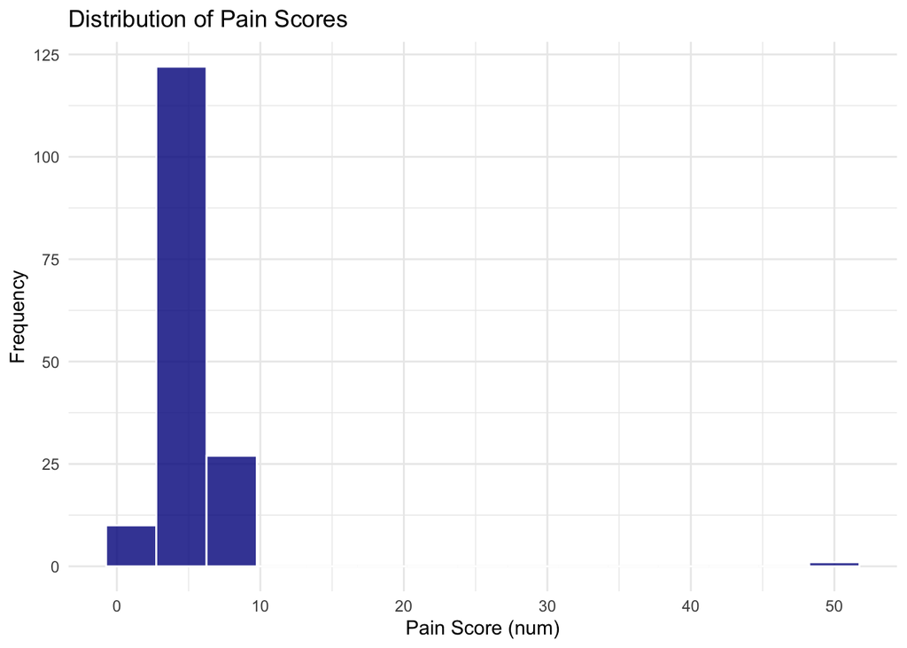

```r
ggplot(data = df_raw, aes(x = pain)) +
  geom_histogram(bins = 15, fill = "darkblue", color = "white", alpha = 0.8) +
  labs(
    title = "Distribution of Pain Scores",
    x = "Pain Score (num)",
    y = "Frequency"
  ) +
  theme_minimal()
```

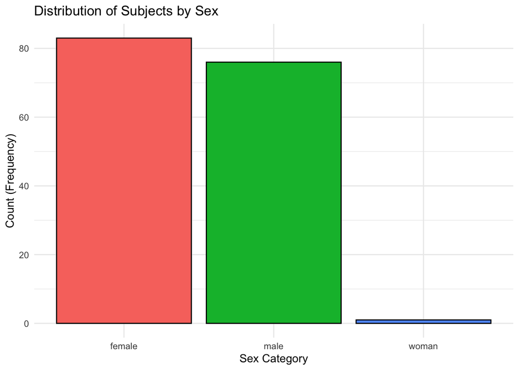

```r
ggplot(data = df_raw, aes(x = sex, fill = sex)) +
  geom_bar(color = "black") +
  labs(
    title = "Distribution of Subjects by Sex",
    x = "Sex Category",
    y = "Count (Frequency)"
  ) +
  theme_minimal() +
  guides(fill = "none")
```

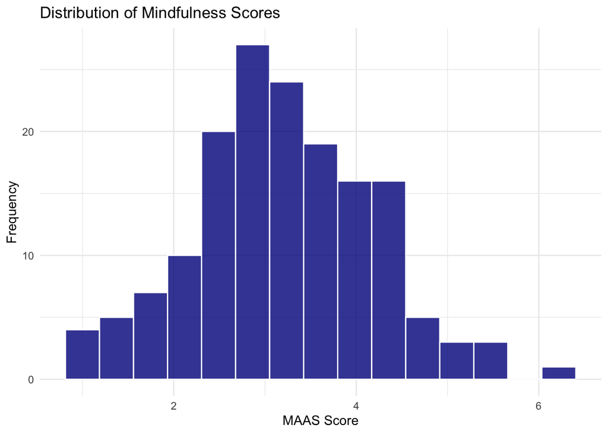

```r
ggplot(data = df_raw, aes(x = mindfulness)) +
  geom_histogram(bins = 15, fill = "darkblue", color = "white", alpha = 0.8) +
  labs(
    title = "Distribution of Mindfulness Scores",
    x = "MAAS Score",
    y = "Frequency"
  ) +
  theme_minimal()
```

#### Correct coding errors

If you find values in the dataset during the EDA, that are not correct based on the provided descriptions of the variables of the dataset please correct them here.

Start with the pain:

```r
print(df_raw %>%
  filter(pain > 10)
  )
```

```
## # A tibble: 1 × 12
##   ID      pain sex      age STAI_trait pain_cat cortisol_serum cortisol_saliva
##   <chr>  <dbl> <chr>  <dbl>      <dbl>    <dbl>          <dbl>           <dbl>
## 1 ID_142    50 female    41         44       30           5.85            6.14
## # ℹ 4 more variables: mindfulness <dbl>, weight <dbl>, IQ <dbl>,
## #   household_income <dbl>
```

**Answer** Since the other fields seem normal, I’ll just reduce pain to 10.

```r
df <- df_raw %>%
  mutate(
    sex = case_when(
      sex == "woman" ~ "female",
      sex %in% c("male", "female") ~ sex,
      TRUE ~ NA_character_
    )
  ) %>%
  mutate(
    sex = as.factor(sex)
  ) %>%
  mutate(
    pain = case_when(
      pain > 10 ~ 10,
      TRUE ~ pain
    )
  ) %>%
  mutate(
    mindfulness = case_when(
      mindfulness > 6 ~ 6,
      TRUE ~ mindfulness
    )
  )

print("Sex distinct values")
```

```
## [1] "Sex distinct values"
```

```r
unique(df$sex)
```

```
## [1] female male
## Levels: female male
```

```r
print("Max value of pain:")
```

```
## [1] "Max value of pain:"
```

```r
max(df$pain, na.rm = TRUE)
```

```
## [1] 10
```

```r
print("Max value of mindfulness:")
```

```
## [1] "Max value of mindfulness:"
```

```r
max(df$mindfulness, na.rm = TRUE)
```

```
## [1] 6
```

### Model diagnostics

#### Build the more complex model

In order to test the more complex model for outliers and to test the assumptions first build the model.

```r
# Outcome: pain
# Predictors: age, sex, STAI_trait, pain_cat, mindfulness,
#              cortisol_serum, cortisol_saliva

model_complex <- lm(pain ~ age + sex + STAI_trait + pain_cat +
                           mindfulness + cortisol_serum +
                           cortisol_saliva,
                     data = df)

print(summary(model_complex))
```

```
##
## Call:
## lm(formula = pain ~ age + sex + STAI_trait + pain_cat + mindfulness +
##     cortisol_serum + cortisol_saliva, data = df)
##
## Residuals:
##     Min      1Q  Median      3Q     Max
## -3.2998 -0.7795 -0.0600  0.7258  4.5666
##
## Coefficients:
##                 Estimate Std. Error t value Pr(>|t|)
## (Intercept)      0.98548    1.79369   0.549  0.58353
## age             -0.02133    0.02513  -0.849  0.39731
## sexmale          0.27657    0.21904   1.263  0.20865
## STAI_trait      -0.02403    0.02902  -0.828  0.40908
## pain_cat         0.09500    0.02996   3.171  0.00184 **
## mindfulness     -0.10670    0.13012  -0.820  0.41350
## cortisol_serum   0.14400    0.25538   0.564  0.57368
## cortisol_saliva  0.49503    0.26206   1.889  0.06080 .
## ---
## Signif. codes:  0 '***' 0.001 '**' 0.01 '*' 0.05 '.' 0.1 ' ' 1
##
## Residual standard error: 1.294 on 152 degrees of freedom
## Multiple R-squared:  0.352,  Adjusted R-squared:  0.3221
## F-statistic: 11.79 on 7 and 152 DF,  p-value: 5.996e-12
```

```r
#### Checking for influential outliers
```

Check for outlier values in the model.

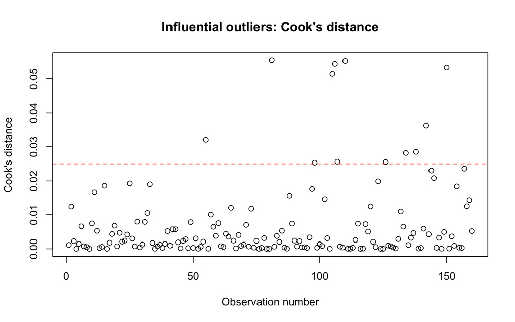

```r
cooks_d <- cooks.distance(model_complex)

# define the cutoff (rule of thumb: 4 / n)
n <- nobs(model_complex)
cutoff <- 4 / n

plot(cooks_d,
     main = "Influential outliers: Cook's distance",
     ylab = "Cook's distance",
     xlab = "Observation number")
# Add a horizontal line for the cutoff
abline(h = cutoff, col = "red", lty = 2)
```

```r
influential_points <- which(cooks_d > cutoff)
cat("--- Observations exceeding Cook's distance cutoff (4/n) ---\n")
```

```
## --- Observations exceeding Cook's distance cutoff (4/n) ---
```

```r
print(influential_points)
```

```
##  55  81  98 105 106 107 110 126 134 138 142 150
##  55  81  98 105 106 107 110 126 134 138 142 150
```

```r
print(cooks_d[influential_points])
```

```
##         55         81         98        105        106        107        110
## 0.03202715 0.05546740 0.02534212 0.05142819 0.05438713 0.02563854 0.05523703
##        126        134        138        142        150
## 0.02552846 0.02817712 0.02850762 0.03623861 0.05330600
```

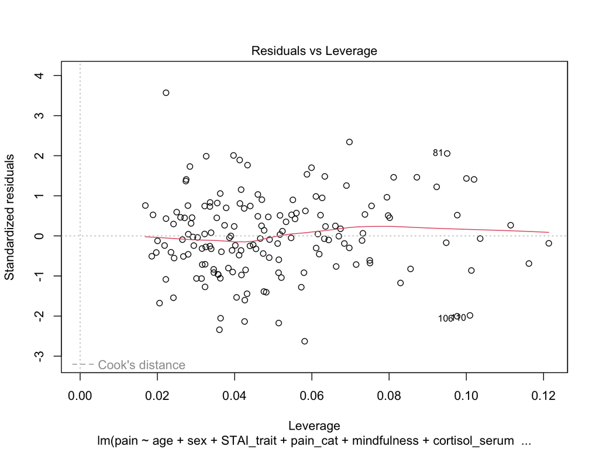

```r
# The red dashed lines are Cook's distance contours
plot(model_complex, which = 5)
```

#### Checking assumptions

Check the normality assumption.

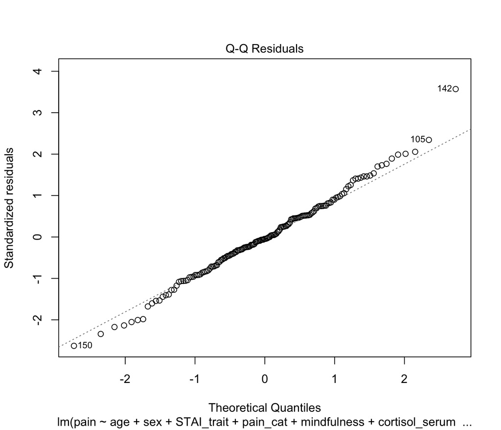

```r
#  Q-Q plot
plot(model_complex, which = 2)
```

```r
model_residuals <- residuals(model_complex)
shapiro_test_result <- shapiro.test(model_residuals)
cat("--- Shapiro-Wilk Normality Test ---\n")
```

```
## --- Shapiro-Wilk Normality Test ---
```

```r
print(shapiro_test_result)
```

```
##
##  Shapiro-Wilk normality test
##
## data:  model_residuals
## W = 0.99236, p-value = 0.5558
```

**The Shapiro-Wilks test is not significant so we can’t reject the null hypothesis of the data having normal distribution.**

Check the linearity assumption.

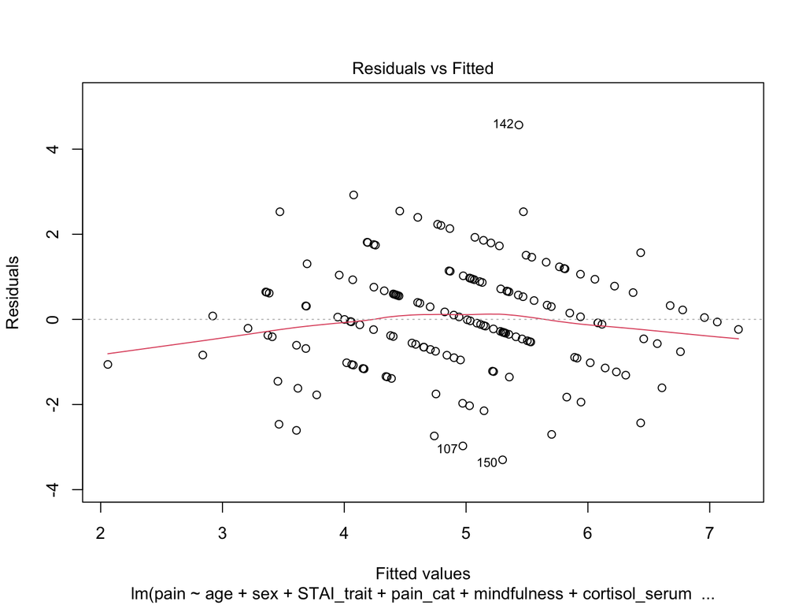

```r
plot(model_complex, which = 1)
```

```r
reset_test_result <- resettest(model_complex)

cat("--- Ramsey RESET test for linearity ---\n")
```

```
## --- Ramsey RESET test for linearity ---
```

```r
print(reset_test_result)
```

```
##
##  RESET test
##
## data:  model_complex
## RESET = 1.5009, df1 = 2, df2 = 150, p-value = 0.2263
```

Check the homoscedasticty assumption (homogeneity of variance).

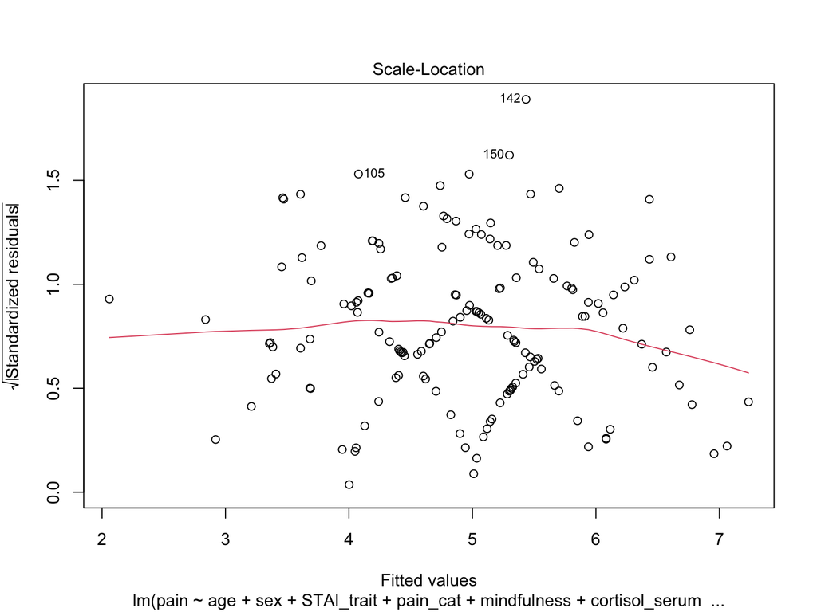

```r
# "Scale-Location" plot
plot(model_complex, which = 3)
```

```r
# Run the Breusch-Pagan test
bp_test_result <- bptest(model_complex)
cat("--- Breusch-Pagan Test for Homoscedasticity ---\n")
```

```
## --- Breusch-Pagan Test for Homoscedasticity ---
```

```r
print(bp_test_result)
```

```
##
##  studentized Breusch-Pagan test
##
## data:  model_complex
## BP = 6.8739, df = 7, p-value = 0.4421
```

**Answer** Since the BP test is not significant, we can say the condition of homoscedasticty is not violated.

Check the multicollinearity assumption.

(VIF above 5), or a VIF threshold of 3 is recommended in this paper: http://onlinelibrary.wiley.com/doi/10.1111/j.2041-210X.2009.00001.x/full

Some info about VIF: https://statisticalhorizons.com/multicollinearity http://blog.minitab.com/blog/understanding-statistics/handling-multicollinearity-in-regression-analysis

```r
vif_values <- vif(model_complex)

cat("--- Variance Inflation Factor (VIF) ---\n")
```

```
## --- Variance Inflation Factor (VIF) ---
```

```r
print(vif_values)
```

```
##             age             sex      STAI_trait        pain_cat     mindfulness
##        1.526782        1.144045        2.123048        1.946766        1.522919
##  cortisol_serum cortisol_saliva
##        6.093917        6.657596
```

**Answer** Based on the VIF scores it is visible that cortisol_serum and cortisol_saliva are way above threshold. Based on the statisticalhorizons article, this doesn’t fall into the categories where we could ignore this. Having read the minitab article, I’ve decided to drop the saliva cortisol, as it is mentioned, serum is a better predictor.

### Making decision based on model diagnostics

If based on the assumption tests you decide to drop a predictor variable you should do that here. Create your updated model.

```r
model_complex_final <- lm(pain ~ age + sex + STAI_trait + pain_cat + mindfulness + cortisol_serum, data = df)
```

#### Checking outliers of the updated model

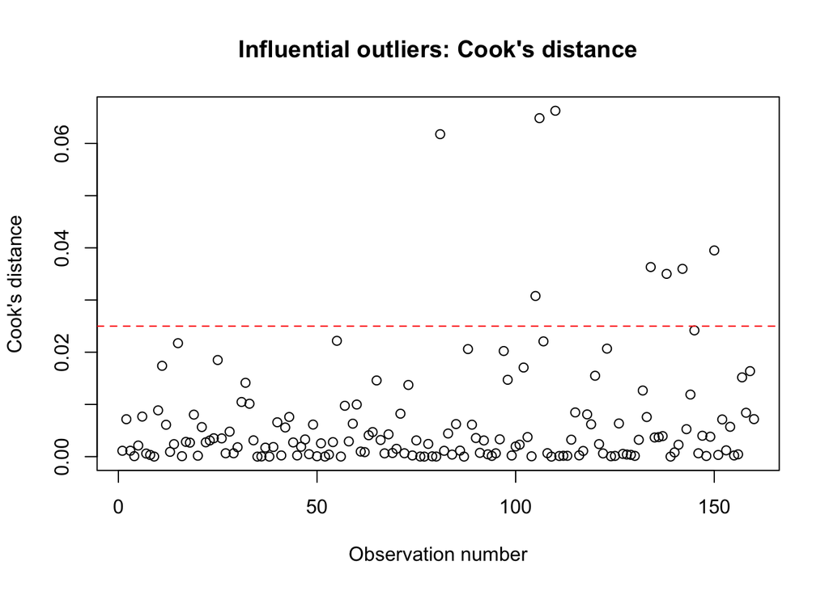

```r
cooks_d <- cooks.distance(model_complex_final)

# define the cutoff (rule of thumb: 4 / n)
n <- nobs(model_complex_final)
cutoff <- 4 / n

plot(cooks_d,
     main = "Influential outliers: Cook's distance",
     ylab = "Cook's distance",
     xlab = "Observation number")
# Add a horizontal line for the cutoff
abline(h = cutoff, col = "red", lty = 2)
```

```r
influential_points <- which(cooks_d > cutoff)
cat("--- Observations exceeding Cook's distance cutoff (4/n) ---\n")
```

```
## --- Observations exceeding Cook's distance cutoff (4/n) ---
```

```r
print(influential_points)
```

```
##  81 105 106 110 134 138 142 150
##  81 105 106 110 134 138 142 150
```

```r
print(cooks_d[influential_points])
```

```
##         81        105        106        110        134        138        142
## 0.06177173 0.03077607 0.06484143 0.06626041 0.03631803 0.03501264 0.03597774
##        150
## 0.03950284
```

#### Checking assumptions of the updated model

Normality assumption

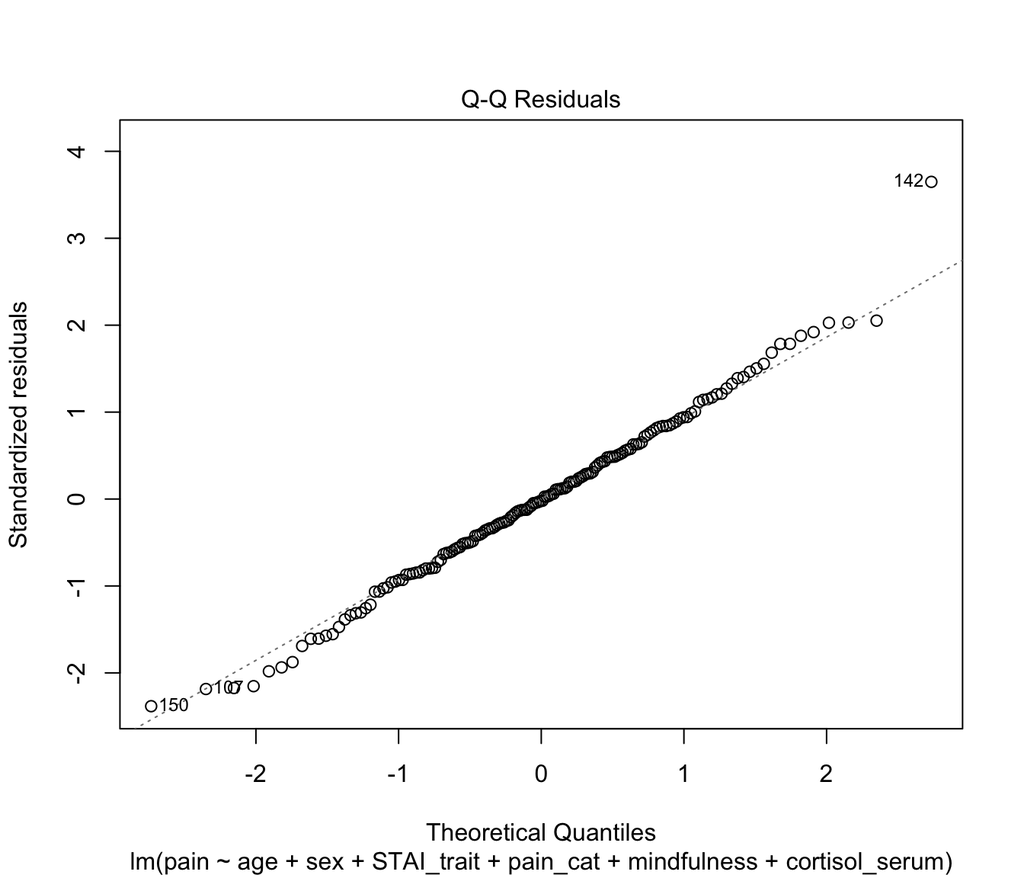

```r
#  Q-Q plot
plot(model_complex_final, which = 2)
```

```r
model_residuals <- residuals(model_complex_final)
shapiro_test_result <- shapiro.test(model_residuals)
cat("--- Shapiro-Wilk Normality Test ---\n")
```

```
## --- Shapiro-Wilk Normality Test ---
```

```r
print(shapiro_test_result)
```

```
##
##  Shapiro-Wilk normality test
##
## data:  model_residuals
## W = 0.99182, p-value = 0.4946
```

**Answer** **Shapiro-Wilks is still not significant, the Q-Q residuals plot is still okay(ish) with a heavy tail.**

Linearity assumption

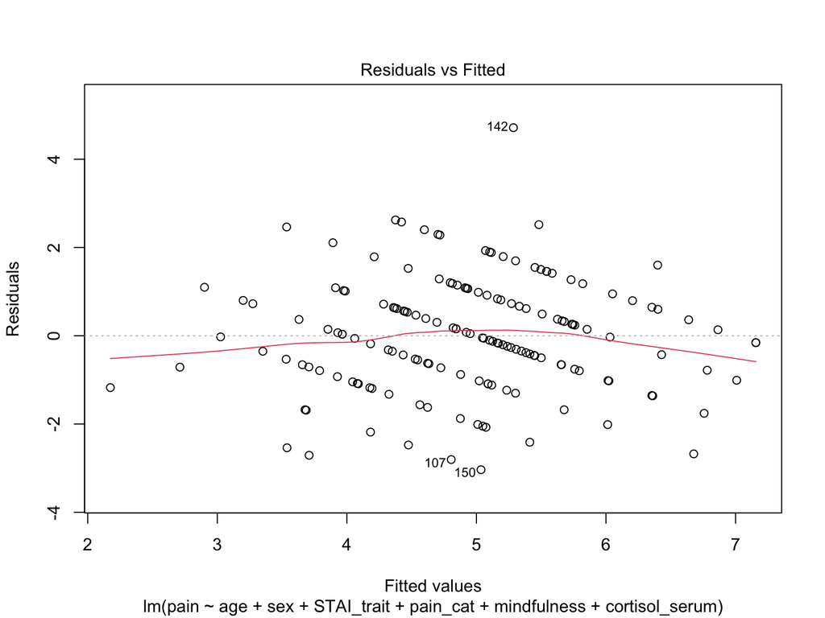

```r
plot(model_complex_final, which = 1)
```

```r
reset_test_result <- resettest(model_complex_final)

cat("--- Ramsey RESET test for linearity ---\n")
```

```
## --- Ramsey RESET test for linearity ---
```

```r
print(reset_test_result)
```

```
##
##  RESET test
##
## data:  model_complex_final
## RESET = 1.7942, df1 = 2, df2 = 151, p-value = 0.1698
```

**Answer** The Ramsey RESET test is still not significant.

Homoscedasticty assumption (homogeneity of variance)

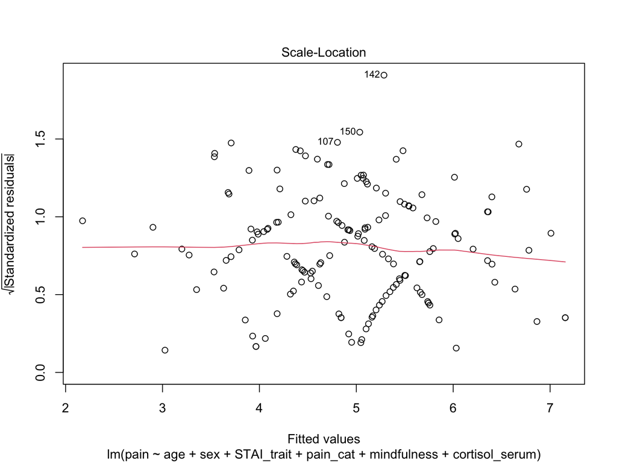

```r
# This plot (which = 3) is the standard "Scale-Location" plot
plot(model_complex_final, which = 3)
```

```r
# Run the Breusch-Pagan test
bp_test_result <- bptest(model_complex_final)
cat("--- Breusch-Pagan Test for Homoscedasticity ---\n")
```

```
## --- Breusch-Pagan Test for Homoscedasticity ---
```

```r
print(bp_test_result)
```

```
##
##  studentized Breusch-Pagan test
##
## data:  model_complex_final
## BP = 6.8275, df = 6, p-value = 0.3371
```

**Answer** BP test is still not significant, and the plot shows a quite flat red line, which seems okay.

Multicollinearity assumption

```r
vif_values <- vif(model_complex_final)

cat("--- Variance inflation factor (VIF) ---\n")
```

```
## --- Variance inflation factor (VIF) ---
```

```r
print(vif_values)
```

```
##            age            sex     STAI_trait       pain_cat    mindfulness
##       1.402905       1.143608       1.937526       1.863172       1.514449
## cortisol_serum
##       1.527828
```

**Answer** After removing the cortisol_saliva, all the VIF values are below 2 which is comforting.

## Model comparison

Create the simple model and get the results of the model that needs to be reported based on the What to report section.

**This is in the What to report section:** Report the results of the simpler model and the more complex model. For both models you should report the model test statistics (adj.R2, F, df, and p value). Also, report the statistics describing the coefficients of the predictors in a table format (unstandardized regression coefficients and 95% confidence intervals, standardized regression coefficients (B and Beta values), and p values).

# Building simple model

```r
model_simple <- lm(pain ~ age + sex, data = df)
```

Coefficients of the predictors

```r
library(gtsummary)

# Unstandardized B
tbl_simple_B <- tbl_regression(
  model_simple,
  intercept = TRUE
) %>%
  modify_header(
    estimate ~ "**B (Estimate)**"
  )

# Standardized Beta (estimate column now is Beta)
tbl_simple_beta <- tbl_regression(
  model_simple,
  intercept = TRUE,
  tidy_fun = tidy_standardize
) %>%
  modify_header(
    estimate ~ "**Beta (Std.)**"
  )

# Combine B and Beta for the simple model
table_simple <- tbl_merge(
  tbls = list(tbl_simple_B, tbl_simple_beta),
  tab_spanner = c("**B (Estimate)**", "**Beta (Std.)**")
)


# Unstandardized B
tbl_complex_B <- tbl_regression(
  model_complex_final,
  intercept = TRUE
) %>%
  modify_header(
    estimate ~ "**B (Estimate)**"
  )

# Standardized Beta
tbl_complex_beta <- tbl_regression(
  model_complex_final,
  intercept = TRUE,
  tidy_fun = tidy_standardize
) %>%
  modify_header(
    estimate ~ "**Beta (Std.)**"
  )

table_complex <- tbl_merge(
  tbls = list(tbl_complex_B, tbl_complex_beta),
  tab_spanner = c("**B (Estimate)**", "**Beta (Std.)**")
)


# Merge the two tables
tbl_merge(
  tbls = list(table_simple, table_complex),
  tab_spanner = c("**Simple Model**", "**Complex Model**")
) %>%
  as_gt() %>%
  gt::tab_header(
    title    = "Model Coefficient Comparison",
    subtitle = "Unstandardized (B) and Standardized (Beta) Coefficients"
  )
```

Model Coefficient Comparison

Unstandardized (B) and Standardized (Beta) Coefficients

| **Characteristic** | **Simple Model** **B (Estimate)** | **Simple Model** **95% CI** | **Simple Model** **p-value** | **Simple Model** **Beta (Std.)** | **Simple Model** **95% CI** | **Complex Model** **B (Estimate)** | **Complex Model** **95% CI** | **Complex Model** **p-value** | **Complex Model** **Beta (Std.)** | **Complex Model** **95% CI** |
| --- | --- | --- | --- | --- | --- | --- | --- | --- | --- | --- |
| (Intercept) | 8.5 | 6.6, 10 | <0.001 | -0.01 | -0.22, 0.20 | 1.7 | -1.8, 5.2 | 0.3 | -0.08 | -0.27, 0.10 |
| age | -0.09 | -0.14, -0.04 | <0.001 | -0.28 | -0.44, -0.13 | -0.03 | -0.08, 0.01 | 0.2 | -0.11 | -0.27, 0.04 |
| sex |  |  |  |  |  |  |  |  |  |  |
| female | — | — |  | — | — | — | — |  | — | — |
| male | 0.04 | -0.43, 0.52 | 0.9 | 0.03 | -0.28, 0.33 | 0.27 | -0.17, 0.70 | 0.2 | 0.17 | -0.11, 0.45 |
| STAI_trait |  |  |  |  |  | -0.01 | -0.06, 0.05 | 0.8 | -0.03 | -0.21, 0.16 |
| pain_cat |  |  |  |  |  | 0.08 | 0.02, 0.14 | 0.005 | 0.25 | 0.08, 0.43 |
| mindfulness |  |  |  |  |  | -0.13 | -0.38, 0.13 | 0.3 | -0.08 | -0.24, 0.08 |
| cortisol_serum |  |  |  |  |  | 0.56 | 0.31, 0.82 | <0.001 | 0.35 | 0.19, 0.52 |

Abbreviation: CI = Confidence Interval

**Answer** In the simple model, age is a significant but moderate negative predictor of the outcome (β = –0.28, p < .001). When additional variables such as Pain Catastrophizing and Cortisol (serum) are included in the complex model, the age effect becomes non-significant and small (β = –0.11, p = .20). In this expanded model, Pain Catastrophizing and Cortisol (serum) remain the only significant predictors, both showing moderate effect sizes (|β| ≈ 0.25–0.35).

```r
stats_simple <- glance(model_simple)
stats_complex <- glance(model_complex_final)

model_stats_df <- bind_rows(
  "Simple Model" = stats_simple,
  "Complex Model" = stats_complex,
  .id = "Model"
) %>%
  # Columns to report (plus AIC/BIC for additional insights)
  select(
    Model,
    `Adj. R-Squared` = adj.r.squared,
    `F-statistic` = statistic,
    `df (num)` = df,
    `df (den)` = df.residual,
    `p-value` = p.value,
    AIC,
    BIC
  )

kable(model_stats_df, Warning = FALSE,
      digits = 3,
      caption = "Overall Model Test Statistics Comparison") %>%
  kable_styling(
    bootstrap_options = c("striped", "hover", "condensed"),
    full_width = FALSE
  )
```

Overall Model Test Statistics Comparison

| Model | Adj. R-Squared | F-statistic | df (num) | df (den) | p-value | AIC | BIC |
| --- | --- | --- | --- | --- | --- | --- | --- |
| Simple Model | 0.069 | 6.881 | 2 | 157 | 0.001 | 592.191 | 604.492 |
| Complex Model | 0.311 | 12.948 | 6 | 153 | 0.000 | 547.933 | 572.535 |

**Answer** The simple model showed a significant but modest overall fit, explaining about 7% of the variance (Adj. R² = .07, F(2,157) = 6.88, p = .001). The complex model provided a clearly better fit, explaining roughly 31% of the variance (Adj. R² = .31, F(6,153) = 12.95, p < .001). Model comparison indices that penalize complexity also favored the complex model (AIC: 592.19 vs. 547.93; BIC: 604.49 vs. 572.54), indicating that the additional predictors meaningfully improve model performance.

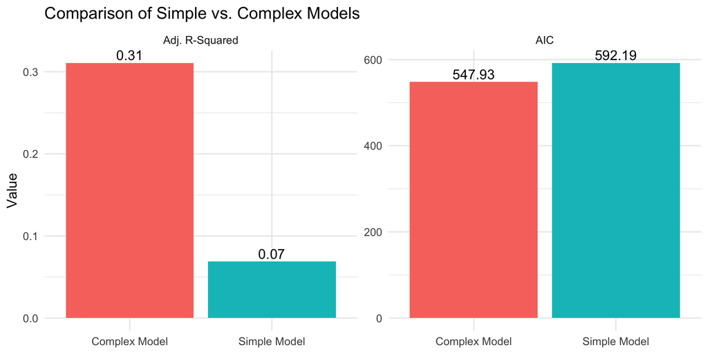

```r
model_stats_long <- model_stats_df %>%
  pivot_longer(
    cols = c("Adj. R-Squared", "AIC"),
    names_to = "Metric",
    values_to = "Value"
  )

ggplot(model_stats_long, aes(x = Model, y = Value, fill = Model)) +
  geom_bar(stat = "identity", position = "dodge", show.legend = FALSE) +
  geom_text(aes(label = round(Value, 2)), vjust = -0.3) +

  # Use facet_wrap to create two separate plots
  facet_wrap(~ Metric, scales = "free_y") +

  labs(
    title = "Comparison of Simple vs. Complex Models",
    x = NULL,
    y = "Value"
  ) +
  theme_minimal(base_size = 14)
```